# Extrovert vs Introvert Behaviors

## Introduction

**Data set**: Extrovert vs. Introvert Behavior Data

**Purpose**: This project investigates how behavior patterns and social engagement metrics can be used to predict extroversion versus introversion, and identifies which features contribute most to model performance and intelligibility.

This analysis is structured to move from descriptive patterns to predictive modeling in order to determine whether behavioral and emotional variables contain sufficient signal to distinguish between extroverted and introverted individuals. Emphasis is placed not only on predictive accuracy but also on interpretability, allowing for examination of which features drive model decisions and how consistently those features perform across multiple modeling approaches.

## Research Objective

**Research Question:** How accurately can personality type be inferred from behavioral data, and which features contribute most to prediction performance?

**Objective:** The goal of this analysis is to examine which behavior and social factors are most predictive of extroversion versus introversion.

## Data Description

**Data set:** To answer my research question, I explored a data set containing a rich collection of behavioral and social data. The data set contained 2900 records and 8 variables: five behavior frequency variables, two psychological response variables, and one target variable.

*Behavior Frequency Variables*

- Time Spent Alone: Hours spent alone daily (0-11)
- Social Event Attendance: Frequency of social events (0-10)
- Going_outside: Frequency of going outside (0-7)
- Friends Circle Size: Number of close friends (0-15)
- Post Frequency: Social media post frequency (0-10)

*Psychological Response Variables*

- Stage Fear: Presence of stage fright (Yes/No)
- Drained after Socializing: Feeling drained after socializing (Yes/No)

*Target Variable*

- Personality: Target variable (Extrovert/Introvert)

Link to data set: [Extrovert vs. Introvert Behavior Data](https://www.kaggle.com/datasets/rakeshkapilavai/extrovert-vs-introvert-behavior-data)

## Data Preparation

### Data Cleaning

```r
# Remove missing values
clean_data <- na.omit(my_data)

# Remove duplicates
library(dplyr)
clean_data <- distinct(clean_data)
```

### Separation of Introvert and Extrovert Data

```r
# Create data frame for introverts
Introvert_data <- data.frame(clean_data)
Introvert_data <- Introvert_data[Introvert_data$Personality == "Introvert",]

# Create data frame for extroverts
Extrovert_data <- data.frame(clean_data)
Extrovert_data <- Extrovert_data[Extrovert_data$Personality == "Extrovert",]
```

### Variable Encoding

```r
# Turning all variables into numerical values
# Make target variable binary. where extrovert = 1, introvert = 0
library(dplyr)
binary_data <- clean_data %>%
  mutate(Personality = recode(Personality,
                              "Extrovert" = 1,
                              "Introvert" = 0))

# Turn categorical variables binary where yes = 1, no = 0
binary_data <- binary_data %>%
  mutate(Stage_fear = recode(Stage_fear,
                             "Yes" = 1,
                             "No" = 0))

binary_data <- binary_data %>%
  mutate(Drained_after_socializing = recode(Drained_after_socializing,
                             "Yes" = 1,
                             "No" = 0))
```

## Exploratory Data Analysis

### Numerical Analysis

#### Summary Statistics: Quantitative Variables

```r
# Load package
library( knitr)

# Calculate introvert means for quantitative variables
Introvert_means <- colMeans(Introvert_data[sapply(Introvert_data, is.numeric)], na.rm=TRUE)

# Calculate extrovert means for quantitative variables
Extrovert_means <- colMeans(Extrovert_data[sapply(Extrovert_data, is.numeric)], na.rm=TRUE)


# Create data frame with quantitative variable means
Summary_statistics <- data.frame(Introvert_Means = Introvert_means, Extrovert_Means = Extrovert_means)

rownames(Summary_statistics) <- c("Hours Spent Alone Daily (0-11)", "Frequency of Social Events (0-10)", "Frequency of Going Outside (0-7)", "Number of Close Friends (0-15)", "Social Media Post Frequency (0-10)")

kable(Summary_statistics,
             caption = "Table 1. Summary Statistics",
             align = 'c',
             col.names = c("Introvert Means", "Extrovert Means"))
```

Table 1. Summary Statistics

|  | Introvert Means | Extrovert Means |
| --- | --- | --- |
| Hours Spent Alone Daily (0-11) | 6.926421 | 2.139883 |
| Frequency of Social Events (0-10) | 1.929766 | 5.945046 |
| Frequency of Going Outside (0-7) | 1.418060 | 4.612823 |
| Number of Close Friends (0-15) | 3.322185 | 9.079101 |
| Social Media Post Frequency (0-10) | 1.535117 | 5.597835 |

#### Frequency Tables: Categorical Variables

**Stage Fright**

Table 2. Stage fear by personality type. Values are counts with column percentages.

| Introverts | Extroverts |
| --- | --- |
| 75 (8.36%) | 1098 (91.42%) |
| 822 (91.64%) | 103 (8.58%) |

**Drained After Socializing**

Table 3. Drained after socializing by personality type. Values are counts with column percentages.

| Introverts | Extroverts |
| --- | --- |
| 75 (8.36%) | 1098 (91.42%) |
| 822 (91.64%) | 103 (8.58%) |

### Visual Analysis

#### Quantitative Data (boxplots)

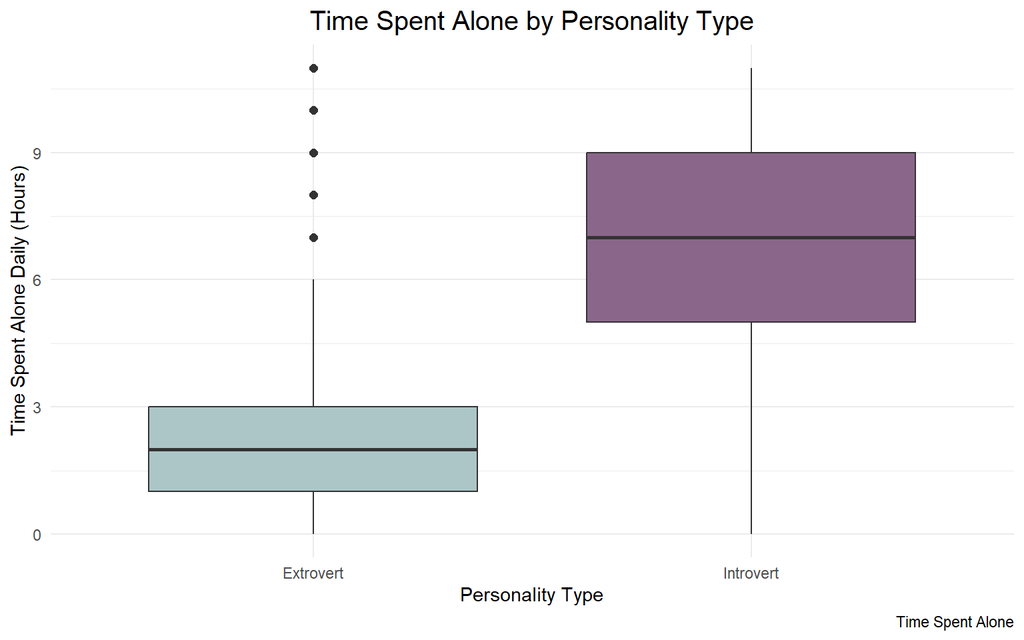

*Figure 1. Time Spent Alone*

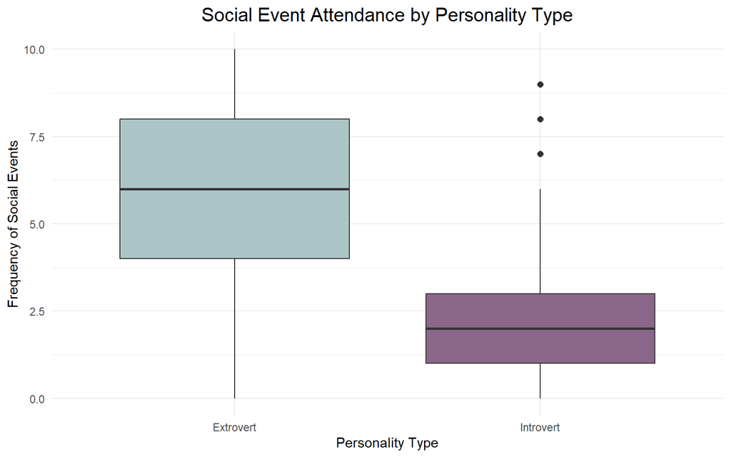

*Figure 2. Social Event Attendance*

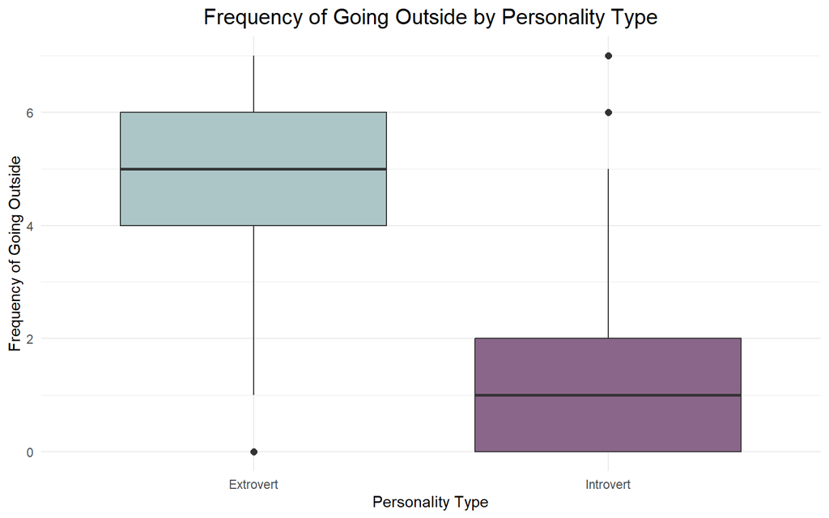

*Figure 3. Frequency of Going Outside*

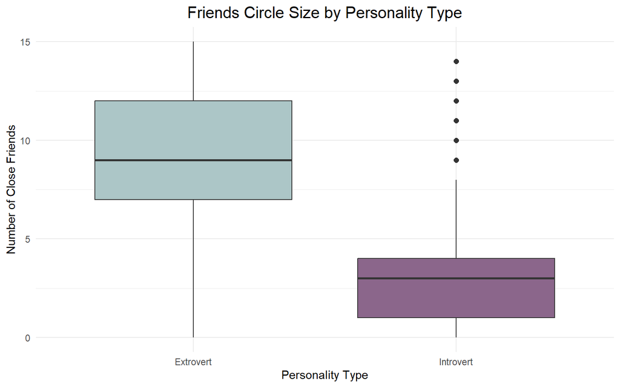

*Figure 4. Number of Close Friends*

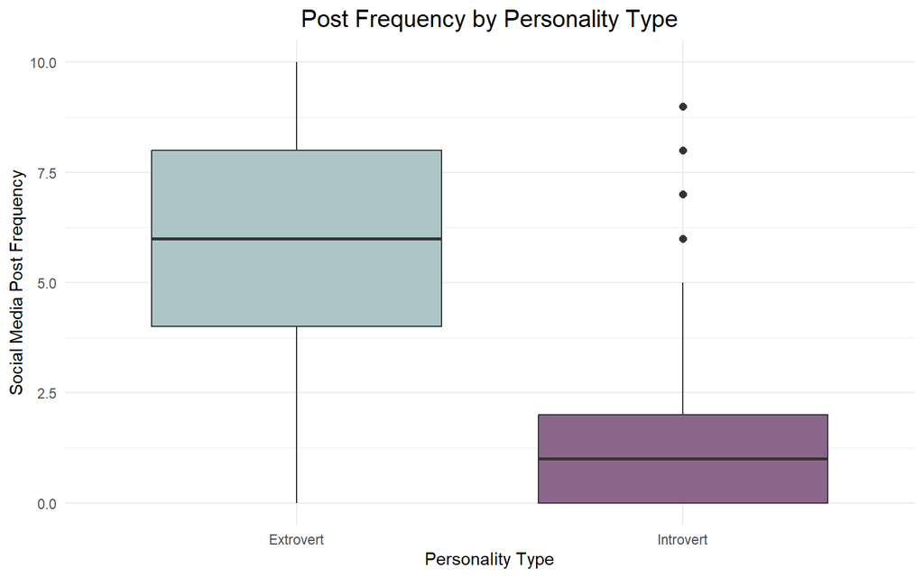

*Figure 5. Social Media Post Frequency*

#### Categorical Data (stacked bar charts)

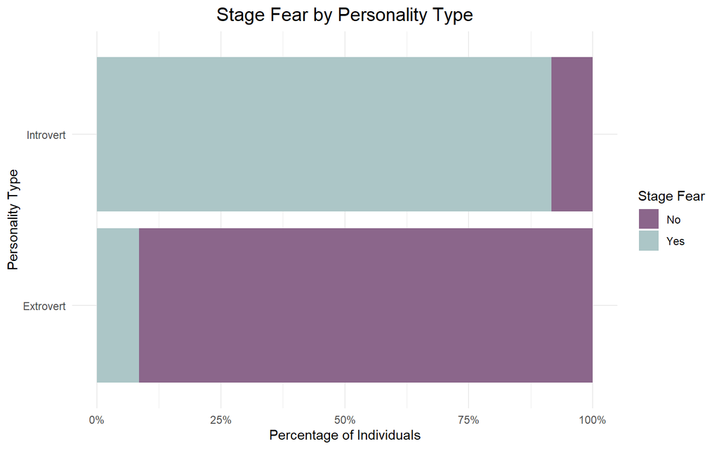

*Figure 6. Stage Fright*

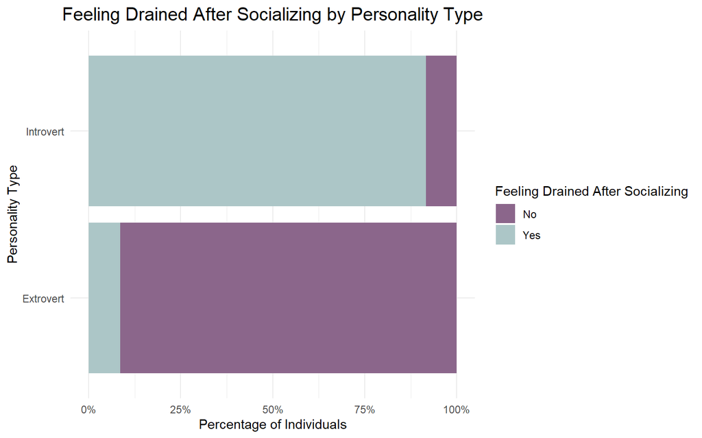

*Figure 7. Feeling Drained After Socializing*

### EDA Analysis Summary

The exploratory analysis suggests the presence of highly separable patterns between personality groups. Emotional response variables displayed particularly strong differentiation, raising the possibility that a small subset of predictors could dominate classification performance. This preliminary observation informed the modeling strategy by motivating the use of both interpretable models and feature selection methods to evaluate whether high predictive accuracy resulted from distributed behavioral signals or from a limited number of highly informative variables.

#### Quantitative Variables

Extroverts display substantially higher average levels of social engagement, including social event attendance, frequency of going outside, size of close friend circles and social media posting. In contrast, introverts spend considerably more time alone per day. The magnitude of these differences suggest that these behavioral frequency measures are likely to be strong predictors of personality type.

#### Categorical Variables

Emotional response variables demonstrate pronounced separation between groups. Introverts are far more likely to report experiencing stage fright and feeling drained after socializing, while extroverts overwhelmingly report the absence of both. These patterns indicate that emotional reactions to social interaction may play a particularly important role in distinguishing personality types.

## Modeling Approach

To evaluate how behavioral and emotional variables contribute to personality classification, this analysis employs a supervised learning framework with personality type (extrovert vs. introvert) as a binary outcome. The modeling strategy prioritizes both predictive performance and interpretability in order to determine not only how accurately personality can be predicted, but also which features drive classification decisions.

Logistic regression was selected as the primary modeling approach due to its suitability for binary outcomes and its ability to provide interpretable estimates of predictor influence through odds ratios. This framework enables direct assessment of how behavioral frequency measures and emotional response variables relate to the probability of extroversion while maintaining transparency in model interpretation.

The dataset was partitioned into training and testing subsets using an 80/20 split to evaluate model generalization on unseen data. A baseline classifier based on majority class prediction was first established to provide a reference point for assessing whether more complex models meaningfully improve predictive performance beyond naive classification.

To examine model stability and reduce the risk of overfitting, feature selection methods were incorporated, including LASSO regularization to identify the most influential predictors and evaluate whether a reduced model could achieve comparable performance to the full specification. Model evaluation relied on multiple performance metrics, including accuracy, confusion matrices and the area under the ROC curve (AUC), ensuring that conclusions were not based solely on overall accuracy.

Finally, complementary nonlinear models, including decision trees and ensemble-based approaches, were implemented to assess whether more flexible algorithms could capture interactions or nonlinear relationships beyond those modeled by logistic regression. Comparing linear and nonlinear approaches provided insight into whether predictive performance was driven by complex relationships among variables or by a small number of dominant predictors.

## Baseline Model

A baseline model was constructed by predicting the majority class for all observations. This model provides a reference point for evaluating whether more complex models meaningfully improve classification performance beyond naive prediction.

```r
library(caret)

# Create the train/test split
set.seed(123)
train_index <- createDataPartition(binary_data$Personality, p = 0.8, list=FALSE)

# Create training and testing datasets
# Train: contains 80% of rows used to fit models
train <- binary_data[train_index, ]
# Test: contains the remaining 20% used to evaluate performance
test <- binary_data[-train_index, ]
```

```r
# Baseline model: majority class prediction
# Proportion of extroverts in the training data
baseline_prob <- mean(train$Personality)

# If extroverts are majority, then predict 1, otherwise predict 0
baseline_pred <- ifelse(baseline_prob > 0.5,1,0)

# Measures the proportions of correct predictions in test set
baseline_accuracy <- mean(test$Personality == baseline_pred)
baseline_accuracy
```

```
## [1] 0.5513126
```

**Majority Class:** Extrovert

**Baseline Accuracy:** 0.5513126

In this data set, *extroverts* represent the majority class, and the baseline model therefore predicts “Extrovert” for every individual. When evaluated on the held-out test set, the baseline model achieved an accuracy of approximately *55.13%*. This performance reflects the underlying class distribution and does not incorporate any behavior or emotional predictors. As a result, the baseline accuracy serves as a lower bound for model performance and provides a benchmark against which more informative models are evaluated.

The following sections assess whether incorporating behavior and emotional variables improves predictive performance beyond this baseline.

## Logistic Regression Analysis

A logistic regression model was fit using the training data to estimate the probability of an individual being classified as an extrovert based on behavioral frequency and emotional response variables. All available predictors were included to assess their joint contribution to personality classification.

### Model Estimation

The model was estimated using a binomial logistic regression framework. To improve interpretability, coefficient estimates were exponentiated and present as odds ratios, with 95% confidence intervals. The intercepts and any predictors were undefined coefficients due to multicollinearity were excluded from the results table.

```r
log_model <- glm(Personality ~ ., data = train, family = binomial)

library(knitr)
library(broom)

# Filter out intercept and NA rows
logit_or_clean <- tidy(
  log_model,
  exponentiate = TRUE,
  conf.int = TRUE
) %>%
  filter(term!= "(Intercept)", !is.na(estimate))

# Relabel terms
logit_or_clean$term <- c(
  "Time Spent Alone",
  "Stage Fear",
  "Social Event Attendance",
  "Going Outside",
  "Friends Circle Size",
  "Post Frequency"
)

# Create table
kable(
  logit_or_clean,
  digits=4,
  caption = "Table 4. Odds Ratios for Logistic Regression Predicting Extroversion"
)
```

Table 4. Odds Ratios for Logistic Regression Predicting Extroversion

| term | estimate | std.error | statistic | p.value | conf.low | conf.high |
| --- | --- | --- | --- | --- | --- | --- |
| Time Spent Alone | 1.3024 | 0.0525 | 5.0306 | 0.0000 | 1.1772 | 1.4468 |
| Stage Fear | 0.0000 | 0.8719 | -12.6143 | 0.0000 | 0.0000 | 0.0001 |
| Social Event Attendance | 0.8234 | 0.0655 | -2.9671 | 0.0030 | 0.7232 | 0.9352 |
| Going Outside | 0.7119 | 0.0904 | -3.7598 | 0.0002 | 0.5949 | 0.8482 |
| Friends Circle Size | 0.8427 | 0.0427 | -4.0090 | 0.0001 | 0.7739 | 0.9151 |
| Post Frequency | 0.8931 | 0.0625 | -1.8087 | 0.0705 | 0.7890 | 1.0087 |

### Coefficient Interpretation

Odds ratios greater than 1 indicate increased odds of being classified as an extrovert, while odds ratios below 1 indicate decreased odds of extroversion.

Although exploratory analyses showed that introverts spend more time alone on average, the positive association between time spent alone and extroversion observed in Table 4 reflects a conditional effect after controlling for stage fear and social engagement variables. Holding these factors constant, each additional hour spent alone was associated with approximately a 30.24% increase in the odds of being classified as an extrovert, suggesting that time spent alone may capture intentional or restorative solitude rather than social avoidance.

Stage fear emerged as the strongest predictor in the model, with individuals reporting stage fear having near-zero odds of being classified as extroverts. This extreme effect suggests that stage fear almost perfectly separates introverts from extroverts in the dataset.

### Model Diagnostics and Considerations

The variable *Drained After Socializing* was excluded from the final model due to perfect multicollinearity with *Stage Fear.* This likely occurred because both variables were measured as binary “Yes” or “No” responses, rather than on a continuous scale, which increased the likelihood of near-perfect correlation. This overlap reflects a structural property of the data rather than a modeling error.

Overall, the model demonstrated a substantial reduction in deviance relative to the null model, indicating a strong explanatory power. The consistency and magnitude of the estimated effects suggest that behavior frequency and emotional response variables jointly provide meaningful information for distinguishing between extroverted and introverted individuals.

These results indicate that personality classification is strongly associated with both emotional responses to social situations and observable behavior patterns, motivating future evaluation of the model’s predictive performance on unseen data.

## Model Evaluation

The logistic regression model’s predictive performance was evaluated using the held-out test set. We compared its accuracy to a baseline classifier and examined both class-level performance and overall discrimination using ROC curves and AUC values.

### Confusion Matrix

The confusion matrix indicates that the model correctly classified most individuals in both personality categories. Specifically, 172 introverts and 210 extroverts were correctly predicted, while 16 introverts and 21 extroverts were misclassified. This model demonstrates balanced performance across both classes, despite a slight class imbalance in the data set.

```r
library(caret)
library(knitr)

# Predict on test set
pred_prob <- predict(log_model, newdata = test, type="response")
pred_class <- ifelse(pred_prob > 0.5, 1,0)

# Confusion matrix
conf_mat <- confusionMatrix(factor(pred_class), factor(test$Personality))
cm <- as.data.frame.matrix(conf_mat$table)

Predictors <- c(0,1)
cm <- cbind(Predictors, cm)
colnames(cm) <- c("Prediction", "Reference 0", "Reference 1")

kable(cm,
      row.names=FALSE,
      align = 'c',
      caption = "Table 5. Confusion Matrix for Logistic Regression")
```

Table 5. Confusion Matrix for Logistic Regression

| Prediction | Reference 0 | Reference 1 |
| --- | --- | --- |
| 0 | 172 | 21 |
| 1 | 16 | 210 |

### Accuracy and Class-Level Metrics

The overall test accuracy was **91.17%**, substantially higher than the baseline accuracy of 55.13%, which corresponds to always predicting the majority class. This difference is statistically significant (p < 2e-16), indicating the model captures meaningful patterns beyond naive classification.

**Class-level performance is also strong:**

- *Sensitivity (introverts):* 91.49%
  - About *91.49%* of introverts were correctly identified as introverts.
- *Specificity (extroverts):* 90.91%
  - About *90.91%* of extroverts were correctly identified as extroverts.
- *Positive Predictive Value (PPV)*: 89.12%
  - When the model predicts an individual is an introvert, it is correct about *89.12%* of the time.
- *Negative Predictive Value (NPV)*: 92.92%
  - When the model predicts an individual is an extrovert, it is correct about *92.92%* of the time.

Balanced accuracy, which accounts for class imbalance, was *91.20%*, further confirming that the model performs reliably across both classes. The Kappa statistic of *0.8219* indicates strong agreement between predicted and actual classifications beyond chance.

Table 6. Model Performance Metrics for Logistic Regression

|  | Accuracy | P_Value | Sensitivity | Specificity | PPV | NPV | Balanced_Accuracy | Kappa |
| --- | --- | --- | --- | --- | --- | --- | --- | --- |
| Accuracy | 0.9117 | <2e-16 | 0.9149 | 0.9091 | 0.8912 | 0.9292 | 0.912 | 0.8219 |

### ROC Curve and AUC

To assess model discrimination independent of the classification threshold, a ROC curve was generated, and the area under the curve (AUC) was calculated. The model achieved an *AUC of 0.9412*, indicating excellent ability to distinguish between extroverts and introverts.

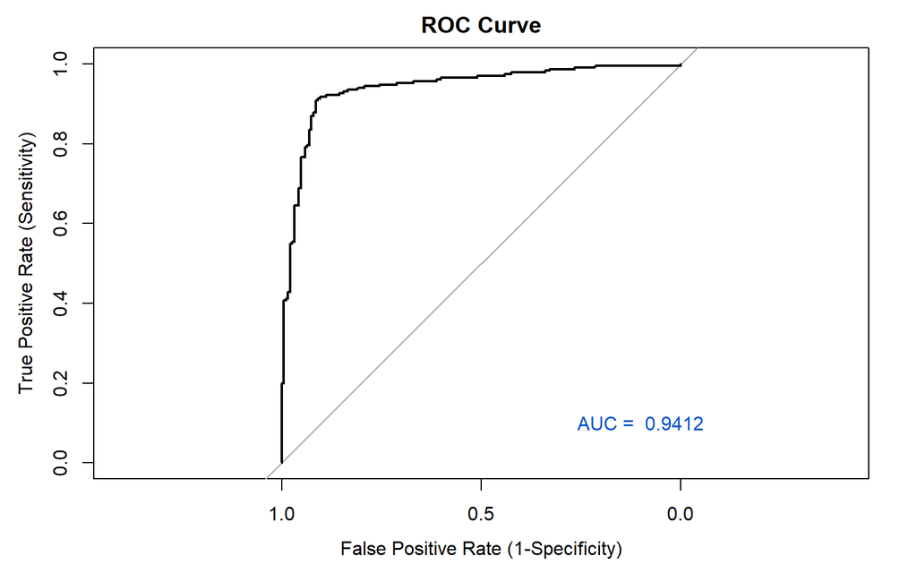

*Figure 8. ROC Curve and AUC*

*Interpretation:* These results demonstrate that the logistic regression model provides strong predictive performance. It not only exceeds baseline accuracy by a wide margin but also maintains balanced sensitivity and specificity, suggesting reliable classification of both personality types. Overall, behavioral frequency and emotional response variables provide substantial information for distinguishing extroverted and introverted individuals.

## Feature Selection and Model Refinement

To improve model interpretability and assess whether all predictors were necessary for accurate classification, feature selection and model refinement techniques were explored. In particular, LASSO regularization was used to identify influential predictors and evaluate whether a reduced model could achieve comparable performance to the full logistic regression model.

### LASSO Regularization

LASSO (Least Absolute Shrinkage and Selection Operator) applies an L1 penalty to the logistic regression coefficients, shrinking less informative coefficients toward zero. This approach performs *automatic variable selection* by effectively removing predictors that contribute little to model performance, while reducing overfitting.

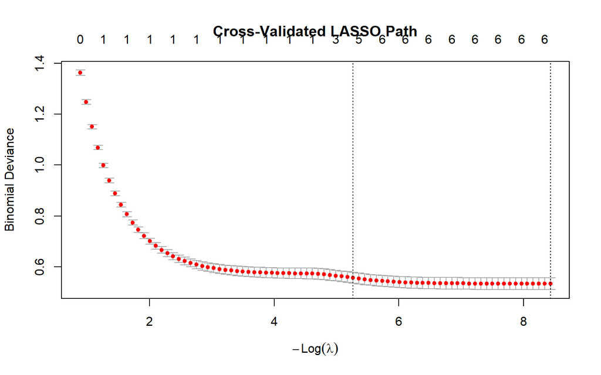

*Figure 9. Cross-Validated LASSO Path*

### Variable Selection

The LASSO procedure retained a subset of predictors with non-zero coefficients at the optimal value of $\lambda$. These variables represent the strongest contributors to personality classification in the data set.

Table 7. Predictors Selected by LASSO Regularization

| Variable | Coefficient |
| --- | --- |
| Time Spent Alone | 0.2557 |
| Stage Fear | -10.7043 |
| Social Event Attendance | -0.1846 |
| Going outside | -0.3240 |
| Friends Circle Size | -0.1650 |
| Post Frequency | -0.1049 |

At the optimal regularization level, six predictors retained non-zero coefficients: *time spent alone, stage fear, social event attendance, going outside, friend circle size* and *post frequency.*

Stage fear emerged as the dominant predictor, with a substantially larger coefficient and magnitude than all the other variables. This indicates that the emotional responses to social situations play a central role in distinguishing between introverted and extroverted individuals. Behavioral frequency variables contributed more modestly but consistently, suggesting that observational social behaviors provide complementary information beyond emotional response measures.

### Reduced Logistic Regression Model

Table 8. Odds Ratio for Reduced Logistic Regression Model

| Term | Estimate | Standard Error | Statistic | P Value | Conf. Low | Conf. High |
| --- | --- | --- | --- | --- | --- | --- |
| Time Spent Alone | 1.3030 | 0.0525 | 5.0383 | 0.0000 | 1.1776 | 1.4474 |
| Stage Fear | 0.0000 | 0.8168 | -12.8296 | 0.0000 | 0.0000 | 0.0001 |
| Social Event Attendance | 0.8207 | 0.0654 | -3.0211 | 0.0025 | 0.7210 | 0.9320 |
| Going Outside | 0.7036 | 0.0904 | -3.8889 | 0.0001 | 0.5879 | 0.8384 |
| Friends Circle Size | 0.8420 | 0.0426 | -4.0324 | 0.0001 | 0.7733 | 0.9143 |

*Reduced Model AIC:*

```
899.2297
```

Overall, these results support the conclusion that personality classification in this data set is primarily driven by a small set of core behavior and emotional response variables.

## Alternative Model Comparison

While logistic regression provided an interpretable and high performing baseline, it assumes linear relationships between predictors and the log-odds of the outcome. To assess whether more flexible models could capture nonlinear relationships or interactions between behavioral and emotional variables, tree-based methods were also explored.

### Decision Tree Model

A classification tree was fit using the same predictors as the reduced logistic regression model. Decision trees offer an interpretable, rule-based approach and can naturally capture nonlinear relationships and interactions without requiring explicit specification.

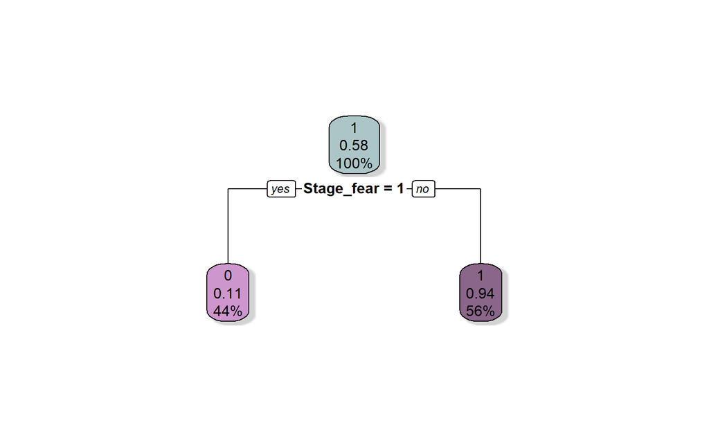

*Figure 10. Decision Tree*

**How to read the decision tree:**

- *Root Node (Top Box):* Before using any predictors, the most common personality classification is class 1 (extroverts), representing 58% of the data set.
- *Left Branch (Yes):* Individuals who report stage fear are more likely to be classified as class 0 (introverted).
  - 11% of individuals who have stage fear are extroverts.
  - 44% of the entire data set have stage fear.
- *Right Branch (No):* Individuals without stage fear are more likely to be classified as class 1 (extroverted).
  - 94% of individuals who don’t have stage fear are extroverts.
  - 56% of the entire data set does not have stage fear.

**Interpretation**: The decision tree identified stage fear as the sole splitting variable, indicating its dominant role in personality classification. Individuals reporting stage fear were overwhelmingly classified as introverted, while those without stage fear were strongly associated with extroversion. The absence of further splits suggests that additional predictors did not provide sufficient improvement in classification performance, reinforcing the importance of stage fear as a primary distinguishing factor.

Table 9. Confusion Matrix for Decision Tree

| Prediction | Reference 0 | Reference 1 |
| --- | --- | --- |
| 0 | 172 | 21 |
| 1 | 16 | 210 |

Table 10. Model Performance Metrics for Decision Tree

|  | Accuracy | P_Value | Sensitivity | Specificity | PPV | NPV | Balanced_Accuracy | Kappa |
| --- | --- | --- | --- | --- | --- | --- | --- | --- |
| Accuracy | 0.9117 | <2e-16 | 0.9149 | 0.9091 | 0.8912 | 0.9292 | 0.912 | 0.8219 |

The decision tree model produced identical classification metrics to the logistic regression model. This occurred because both models relied primarily on *stage fear* as the dominant predictor. The decision tree consisted of a single split on stage fear, while the logistic regression assigned an extremely large coefficient to the same variable. As a result, both models generated identical class predictions across observations, leading to the same confusion matrix and accuracy measures.

### Random Forest Model

A random forest classifier was fit to further assess whether ensemble-based methods could improve performance by averaging across multiple decision trees. Random forests reduce variance relative to a single tree and are well-suited for capturing complex interactions.

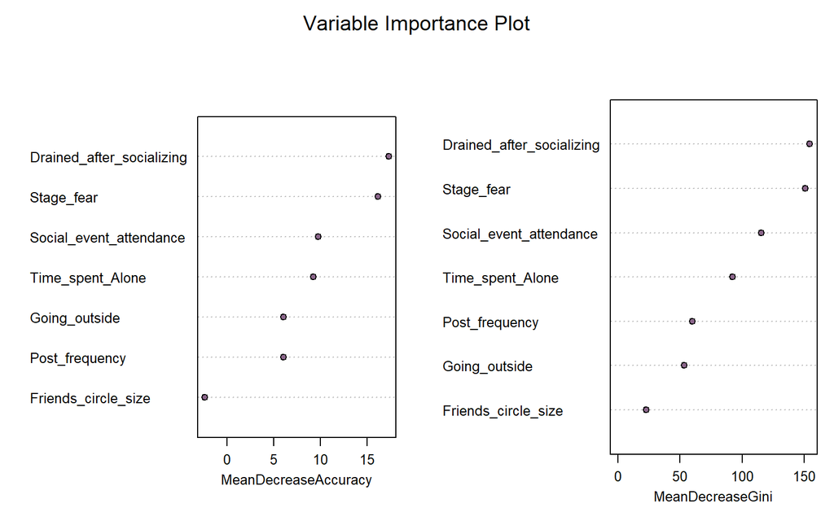

*Figure 11. Variable Importance Plot*

Table 11. Confusion Matrix for Random Model

| Prediction | Reference 0 | Reference 1 |
| --- | --- | --- |
| 0 | 172 | 21 |
| 1 | 16 | 210 |

Table 12. Performance Metrics for Random Model

|  | Accuracy | P_Value | Sensitivity | Specificity | PPV | NPV | Balanced_Accuracy | Kappa |
| --- | --- | --- | --- | --- | --- | --- | --- | --- |
| Accuracy | 0.9117 | <2e-16 | 0.9149 | 0.9091 | 0.8912 | 0.9292 | 0.912 | 0.8219 |

The random forest variable importance plot indicates that emotional response variables, particularly stage fear and feeling drained after socializing, were the most influential predictors under both mean decrease in accuracy and mean decrease in Gini impurity. Behavioral frequency measures, such as social event attendance and time spent alone, contributed moderately to classification performance, while friends circle size had relatively low importance. Despite these differences in relative importance, the random forest model produced identical classification performance to the logistic regression and decision tree models, reinforcing the conclusion that personality classification in this data set is driven by a small number of highly informative predictors.

## Model Comparison Summary

Across all models evaluated, logistic regression, decision tree and random forest, classification performance was nearly identical. This consistency suggests that the relationship between the predictors and personality type is relatively simple and dominated by a small number of highly informative features. Logistic regression achieved comparable performance while offering superior interpretability, making it the preferred model for this analysis.

## Key Findings

This study examined whether behavioral frequency and emotional response variables could predict whether an individual classified as an extrovert or introvert. Across multiple modeling approaches (including logistic regression, decision trees, random forests and LASSO-based feature selection), results were highly consistent, indicating a strong and stable underlying signal in the data.

### Directions of Effects and Practical Interpretation

Although social media post frequency demonstrated a weaker relationship, its effect direction was consistent with the broader pattern of social engagement.

Together, these findings suggest that how individuals emotionally respond to social situations may be more predictive of personality type than how often they engage in social activities. While behavioral patterns provide meaningful context, emotional reactions appear to capture a more fundamental distinction between introverted and extroverted individuals.

## Discussion

### Behavior vs. Emotional Predictors

One of the most notable findings of this analysis is the dominance of emotional response variables over behavioral frequency measures. While extroversion is often operationalized through observational behaviors such as social participation, the results indicate that internal emotional experiences, particularly discomfort or anxiety in social settings, plays a more decisive role in personality classification.

This distinction helps explain why relatively simple models achieved high predictive accuracy as emotional responses may act as high-signal indicators that capture underlying personality traits more directly than behavioral counts alone.

### Real World Applications

From a practical standpoint, these findings suggest that personality assessments or predictive systems may benefit from prioritizing emotional response measures. In applied settings such as education, work space collaboration or mental health screening, understanding how individuals feel during social interactions may be more informative than tracking the frequency of those interactions.

### Alignment With Personality Theory

These results align closely with established personality theory, which characterizes extroversion not only as increased social engagement but also as lower sensitivity to social overstimulation The strong influence of stage fear and feeling drained over socializing reflects this theoretical framework, reinforcing the validity of observed relationships.

## Limitations and Future Work

Several limitations should be considered when interpreting these findings. Many predictors were measured as binary variables, which may oversimplify complex emotional experiences and reduce the ability to capture gradations in social discomfort or engagement. In addition, the extremely strong predictive influence of a small subset of variables, particularly emotional response measures, may obscure more subtle relationships among behavioral predictors and inflate overall model performance. When a limited number of features dominate classification decisions, models may appear highly accurate while providing less insight into broader behavioral patterns.

Future research could incorporate continuous or scaled measures of emotional response to better represent variability in individual experiences. Exploring interaction effects between behavioral and emotional predictors may also clarify how observable actions and internal responses jointly influence personality classification. Alternative classification thresholds and resampling strategies could be examined to evaluate model stability under different decision criteria. Finally, expanding the dataset to include longitudinal observations or richer contextual information may provide a more comprehensive understanding of how personality traits manifest across environments and evolve over time.